# Reproducible Research: Peer Assessment 1

# Description

This is my solution to the first project. I’ve tried to make it as short and sweet as possible to make it easy for me to finish it, and for you to review it. Let me know your thoughts on the feedback!

## Libraries

I’ve used dplyr, lubridate, cowplot and ggplot2. Piece of cake (hopefully!)

# Solution

## Code for reading in the dataset and/or processing the data

First comes first.

```r
library(dplyr)
```

```r
library(ggplot2)
library(lubridate)
library(cowplot)
```

Alright, let’s get down to business:

```r
data<-read.csv(file="activity.csv")
datad<-tbl_df(data)
```

## Histogram of the total number of steps taken each day

First, I grouped the data by using beautiful dplyr and the group_by function. Then, I created a summary with extra columns for the sum, mean and median (I need to say that I dislike Oxford commas).

```r
dataday<-group_by(datad,date)
perday<-summarize(dataday,sum=sum(steps),mean=mean(steps), median=median(steps,na.rm=TRUE))
perday
```

```
## Source: local data frame [61 x 4]
##
##          date   sum     mean median
##        (fctr) (int)    (dbl)  (dbl)
## 1  2012-10-01    NA       NA     NA
## 2  2012-10-02   126  0.43750      0
## 3  2012-10-03 11352 39.41667      0
## 4  2012-10-04 12116 42.06944      0
## 5  2012-10-05 13294 46.15972      0
## 6  2012-10-06 15420 53.54167      0
## 7  2012-10-07 11015 38.24653      0
## 8  2012-10-08    NA       NA     NA
## 9  2012-10-09 12811 44.48264      0
## 10 2012-10-10  9900 34.37500      0
## ..        ...   ...      ...    ...
```

Pretty cool, eh? Now, we plot.

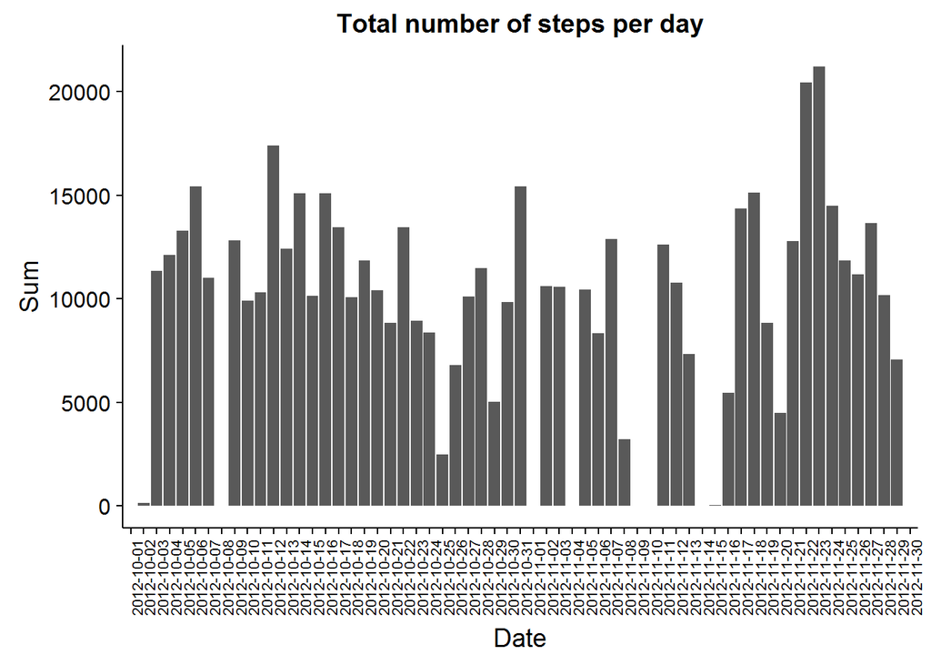

```r
ggplot(perday,aes(x=date,y=sum))+geom_bar(stat="identity")+labs(x = "Date", y = "Sum", title = "Total number of steps per day")+theme(axis.text.x=element_text(angle=90,size=8))
```

Here is something I found while trying to solve this: “If you want the heights of the bars to represent values in the data, use stat=”identity" and map a value to the y aesthetic." Just in case you’re wondering about that.

## Mean and median number of steps taken each day

Already solved with the perday table.

## Time series plot of the average number of steps taken

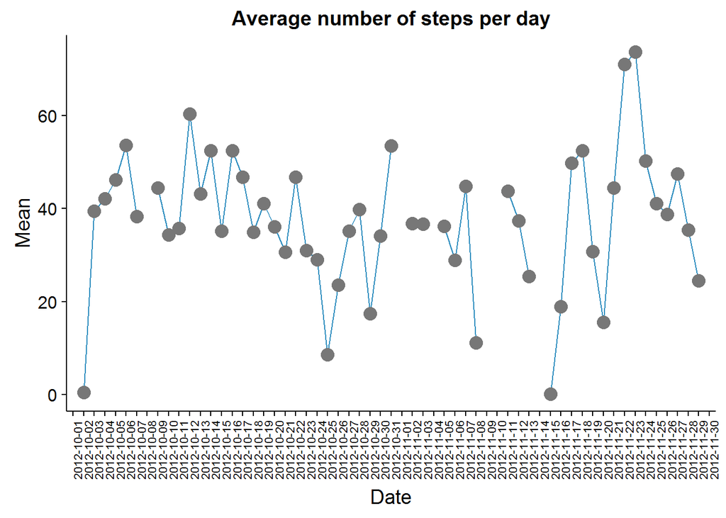

```r
ggplot(perday,aes(x=date,y=mean,group=1))+geom_line(color="#2b8cbe")+geom_point(size=4,color="#777777")+labs(x = "Date", y = "Mean", title = "Average number of steps per day")+theme(axis.text.x=element_text(angle=90,size=8))
```

## The 5-minute interval that, on average, contains the maximum number of steps

```r
length(unique(datad$interval))
```

```
## [1] 288
```

Yup, it works.

So then, I group and summarize my data, and then find the maximum avarage value.

```r
datainterval<-group_by(datad,interval)
perinterval<-summarize(datainterval,mean=mean(steps,na.rm=TRUE))
filter(perinterval,perinterval$mean==max(perinterval$mean,na.rm=FALSE))
```

```
## Source: local data frame [1 x 2]
##
##   interval     mean
##      (int)    (dbl)
## 1      835 206.1698
```

## Code to describe and show a strategy for imputing missing data

Nothing too fancy; I just substituted the values with NA with the mean of the means. So for this, first I calculated meanmean, which is simply a mean of the existing means in the table. Then, I create a copy of the dataset.

```r
meanmean<-mean(perday$mean,na.rm=TRUE)
datad2<-datad
```

I found that substituting was going to take too much time to learn (I promise I will!), so for now, I just took the whole step column out as a vector called stepout, and then I substituted the NA values for the mean of means. Check it out:

```r
stepout<-datad2$steps
stepout[is.na(stepout)] <- meanmean
```

Then, I bring it back in.

```r
datad2<-mutate(datad2,steps2=stepout)
datad2
```

```
## Source: local data frame [17,568 x 4]
##
##    steps       date interval  steps2
##    (int)     (fctr)    (int)   (dbl)
## 1     NA 2012-10-01        0 37.3826
## 2     NA 2012-10-01        5 37.3826
## 3     NA 2012-10-01       10 37.3826
## 4     NA 2012-10-01       15 37.3826
## 5     NA 2012-10-01       20 37.3826
## 6     NA 2012-10-01       25 37.3826
## 7     NA 2012-10-01       30 37.3826
## 8     NA 2012-10-01       35 37.3826
## 9     NA 2012-10-01       40 37.3826
## 10    NA 2012-10-01       45 37.3826
## ..   ...        ...      ...     ...
```

## Histogram of the total number of steps taken each day after missing values are imputed

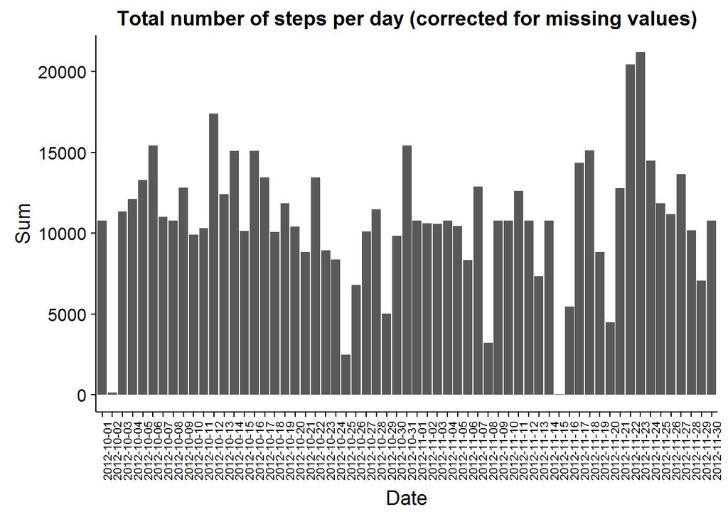

```r
dataday2<-group_by(datad2,date)
perday2<-summarize(dataday2,sum=sum(steps2),mean=mean(steps2), median=median(steps2))

ggplot(perday2,aes(x=date,y=sum))+geom_bar(stat="identity")+labs(x = "Date", y = "Sum", title = "Total number of steps per day (corrected for missing values)")+theme(axis.text.x=element_text(angle=90,size=8))
```

When adding up values like this to the median, you can tell that the values change considerably, and are equal to the mean instead of zeroing as they usually do.

```r
perday2
```

```
## Source: local data frame [61 x 4]
##
##          date      sum     mean  median
##        (fctr)    (dbl)    (dbl)   (dbl)
## 1  2012-10-01 10766.19 37.38260 37.3826
## 2  2012-10-02   126.00  0.43750  0.0000
## 3  2012-10-03 11352.00 39.41667  0.0000
## 4  2012-10-04 12116.00 42.06944  0.0000
## 5  2012-10-05 13294.00 46.15972  0.0000
## 6  2012-10-06 15420.00 53.54167  0.0000
## 7  2012-10-07 11015.00 38.24653  0.0000
## 8  2012-10-08 10766.19 37.38260 37.3826
## 9  2012-10-09 12811.00 44.48264  0.0000
## 10 2012-10-10  9900.00 34.37500  0.0000
## ..        ...      ...      ...     ...
```

For this, I first add the column depending on the day of the week, and then I filter and summarize each category. Finally, I create two plots, a and b.

```r
datad2<-mutate(datad2,weekday=ifelse(wday(ymd(datad2$date))<6,"Weekday","Weekend"))

datawd<-filter(datad2,weekday=="Weekday")
intervalwd<-group_by(datawd,interval)
summarywd<-summarize(intervalwd,sumsteps=sum(steps2))
a<-ggplot(summarywd,aes(x=interval,y=sumsteps,group=1))+geom_line(color="#2b8cbe")+labs(x = "Interval", y = "Steps", title = "Number of steps per interval on weekdays")

datawe<-filter(datad2,weekday=="Weekend")
intervalwe<-group_by(datawe,interval)
summarywe<-summarize(intervalwe,sumsteps=sum(steps2))
b<-ggplot(summarywe,aes(x=interval,y=sumsteps,group=1))+geom_line(color="#d95f0e")+labs(x = "Interval", y = "Steps", title = "Number of steps per interval on weekends")
```

Now we plot!

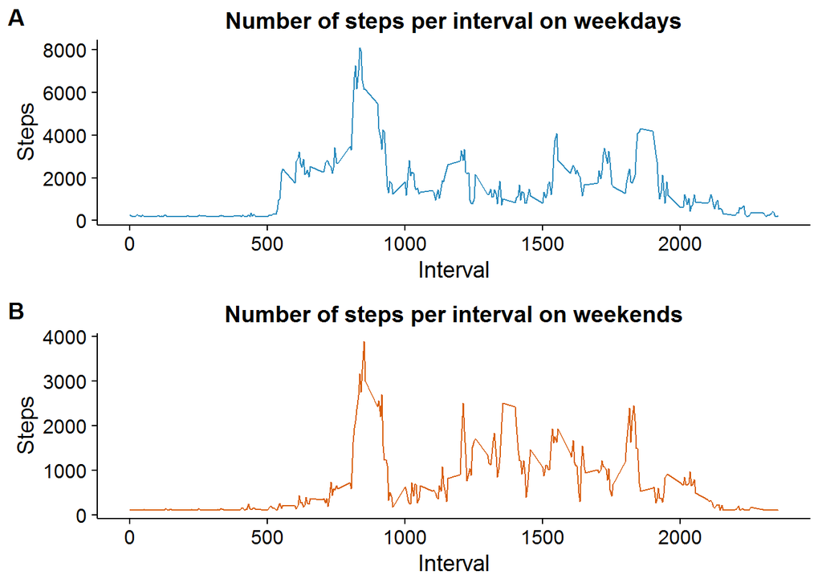

```r
plot_grid(a, b, labels=c("A", "B"), ncol = 1, nrow = 2)
```

## All of the R code needed to reproduce the results (numbers, plots, etc.) in the report

I hope that by ‘code’ it refers to everything I posted above!